# YouTube Recommendations: What the Algorithm really shows us

## Introduction: The Great YouTube Algorithm Mystery

Have you ever wondered if YouTube knows you a little *too* well? Or maybe you’ve even questioned whether those supposedly “random” recommendations are actually random at all? This data story explores what happens to YouTube recommendations when users are logged in versus when they’re browsing anonymously.

Through an observational study of 42 YouTube users’ homepage recommendations, we dive into the patterns, peculiarities, and potential biases of one of the world’s most influential recommendation algorithms. Fair warning: this sample size is much too small to derive any definitive conclusions, but the insights are surprisingly telling!

## The Registration Reality Check

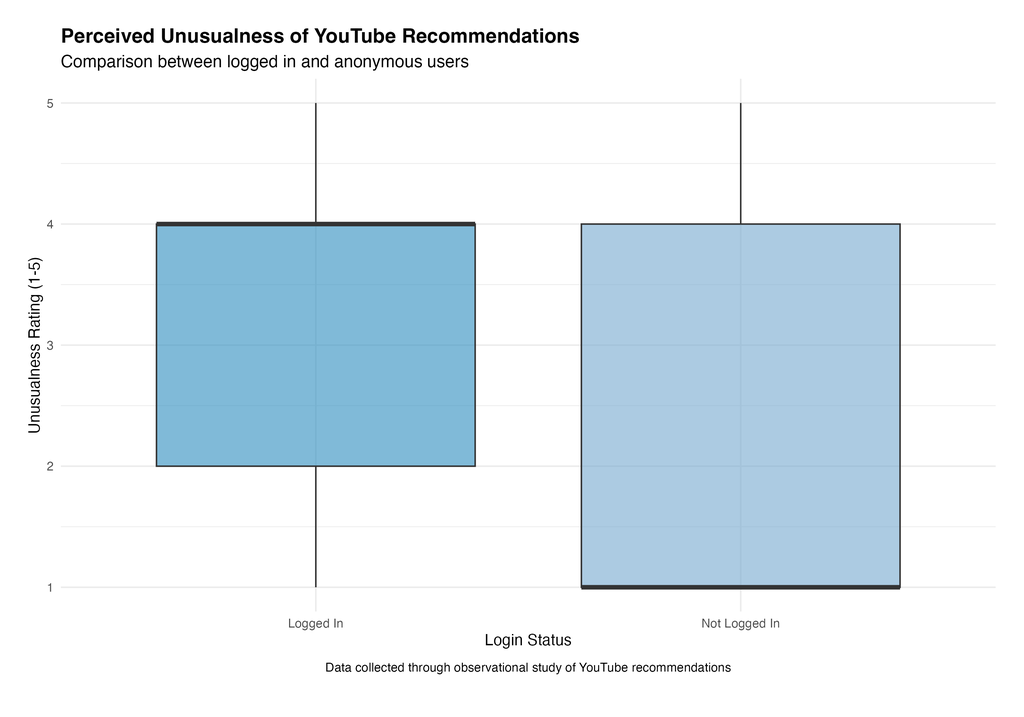

Plot 1: Boxplot showing YouTube recommendation unusualness ratings by login status. Logged-in users cluster around higher unusualness ratings, while anonymous users show a wider range with lower median.

Here’s where things get interesting - when we look at how “unusual” people find their recommendations, logged-in and anonymous users tell completely different stories.

Anonymous users experience the full spectrum of surprise - from “that seems pretty normal” (rating 1) to “where on Earth did that come from?” (rating 5). It’s as if the YouTube algorithm is throwing darts at a board when you’re not logged in.

Meanwhile, logged-in users cluster around rating 4, suggesting their recommendations consistently surprise them in some way. The median tells the story: logged-in users typically rate unusualness as 4, while anonymous users sit at a very predictable 1. Perhaps knowing your viewing history makes YouTube more… experimental?

The lower quartile comparison is particularly revealing - anonymous users bottom out at 1 (completely expected content), while logged-in users start at 2. This suggests that when YouTube doesn’t know who you are, it plays it safe with trending, mainstream content that most people would find familiar.

## What Types of Content Are We Seeing?

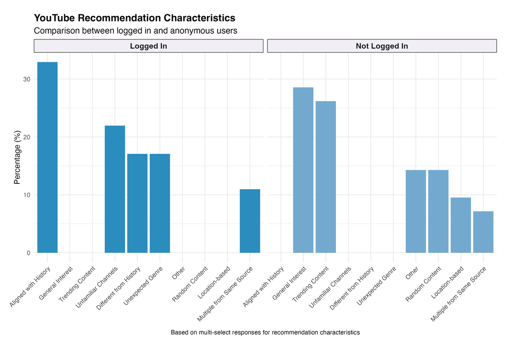

The content breakdown reveals YouTube’s two distinct personalities. For logged-in users, it’s a mixed bag:

- 33% aligned with viewing history (no surprises there)
- 22% featuring unfamiliar channels (YouTube’s attempt to broaden horizons?)
- 17% each for unexpected genres and content different from usual history

For anonymous users, it’s a different algorithm entirely:

- 29% general interest content (safe, broad appeal)
- 26% trending content (what’s popular right now)
- Only 14% each for truly random content or “other” categories

This suggests that YouTube’s algorithm tends to default to the “greatest hits” approach when it doesn’t know you - displaying a steady assortment of trending and broadly appealing content rather than taking risks with anything too controversial or polarizing.

## The Time Factor: When Do We Browse?

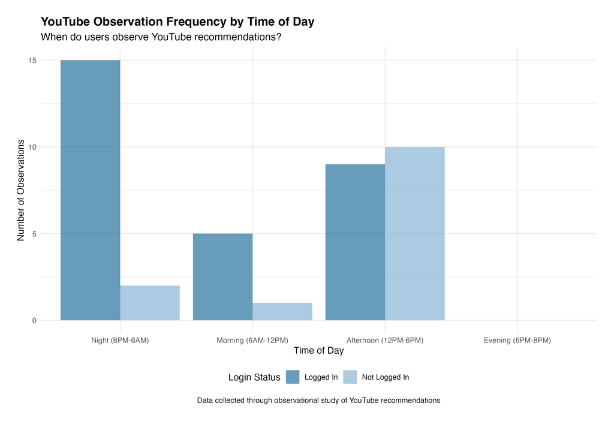

Plot 3: Bar chart showing frequency of YouTube usage by time of day and login status. Most logged-in users browse at night; anonymous users are more active in the afternoon.

Interestingly, no one in our sample browsed during evening hours (6PM-8PM) - perhaps everyone’s too busy with dinner or commuting? The afternoon sees the most balanced split between logged-in and anonymous users (9 vs 10), while mornings heavily favour logged-in users (5 vs 1).

This timing data, while limited by our small sample, hints at when different types of users engage with YouTube. Night browsing is dominated by logged-in users who might be winding down with content tailored to their interests, while daytime browsing shows more anonymous exploration.

## The Reality Check: What We Can (and Can’t) Conclude

Let’s be honest - with 42 responses (29 logged-in, 13 anonymous), we’re barely scratching the surface of the logistics behind YouTube’s recommendation algorithm system. The skewed sample toward logged-in users particularly limits our ability to draw strong conclusions about anonymous browsing patterns.

However, some patterns emerge clearly enough to be noteworthy:

1. YouTube’s algorithm behaves fundamentally differently based on login status
2. Anonymous users receive more predictable, mainstream content
3. Logged-in users get a more diverse (and often surprising) mix of recommendations
4. Browsing patterns vary significantly by time of day

While these findings align with what we might expect from a personalisation algorithm, they raise intriguing questions: Is YouTube’s personalised approach actually more surprising than its anonymous default? And what does this mean for how we discover new content online?

## Final Thoughts: The Algorithm’s Dual Nature

This small glimpse into YouTube’s recommendation system reveals its dual nature - conservative when it doesn’t know you, adventurous when it does. Whether this is by design or emergent behaviour remains an open question.

Perhaps the most telling finding is that knowing your data leads to more unexpected recommendations, not fewer. In trying to personalise our experience, YouTube might actually be making it more unpredictable. Whether that’s a bug or a feature depends on what we’re looking for when we open that app at 1 AM.

The algorithm remains a mystery, but at least now we have a tiny window into its logic.